# plotsrmd

2024-06-01

## Plotting using “MPG” dataset

- Gráfico de dispersión: Crea un gráfico de dispersión que muestre la relación entre displ (desplazamiento del motor) y hwy (millas por galón en carretera).

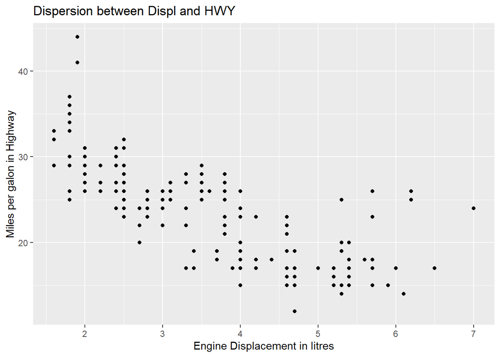

- Boxplot: Crea un boxplot que compare la eficiencia de combustible en carretera (hwy) entre diferentes clases de autos (class).

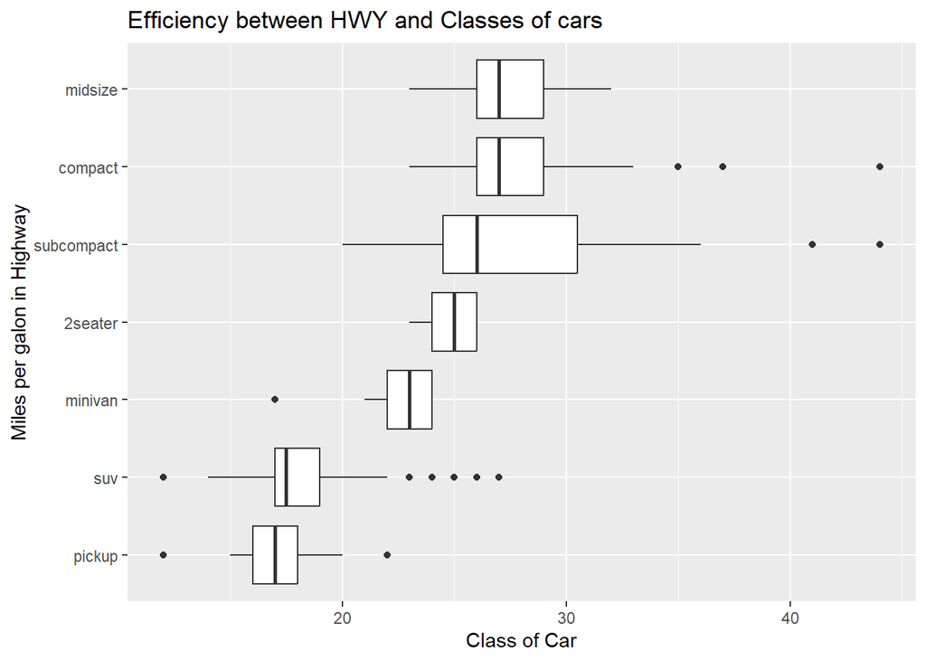

- Histograma: Realiza un histograma de la variable cty (millas por galón en ciudad).

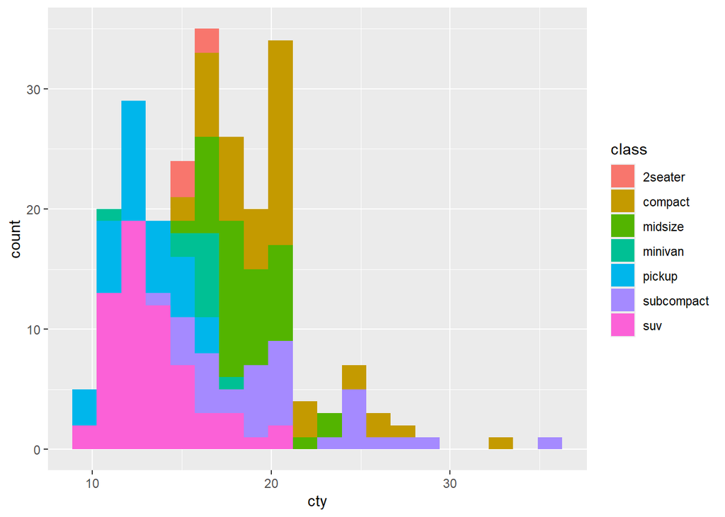

- Gráfico de barras: Crea un gráfico de barras que muestre la cantidad de autos para cada tipo de transmisión (trans).

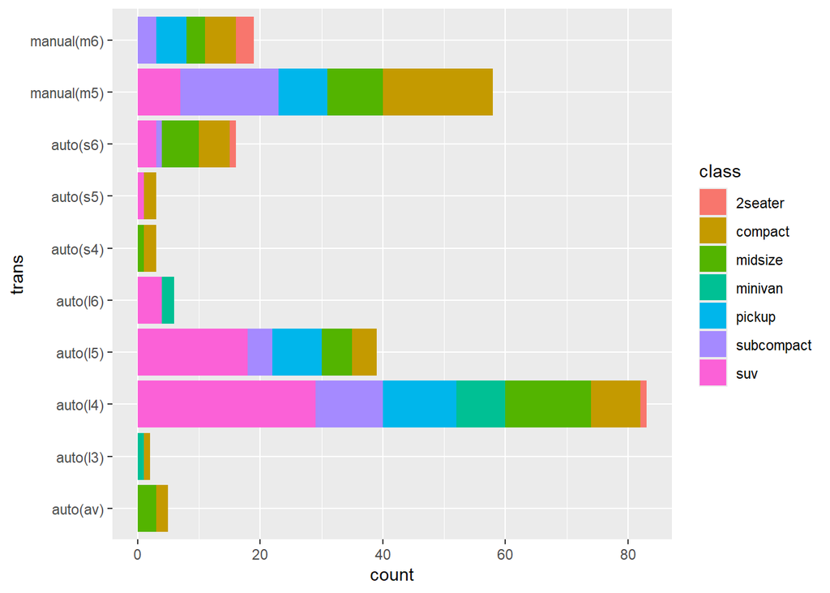

```
## # A tibble: 10 × 2
##    trans      count
##    <chr>      <int>
##  1 auto(av)       5
##  2 auto(l3)       2
##  3 auto(l4)      83
##  4 auto(l5)      39
##  5 auto(l6)       6
##  6 auto(s4)       3
##  7 auto(s5)       3
##  8 auto(s6)      16
##  9 manual(m5)    58
## 10 manual(m6)    19
```

- Facetas: Realiza un gráfico de dispersión de displ vs hwy con facetas por el tipo de tracción (drv).

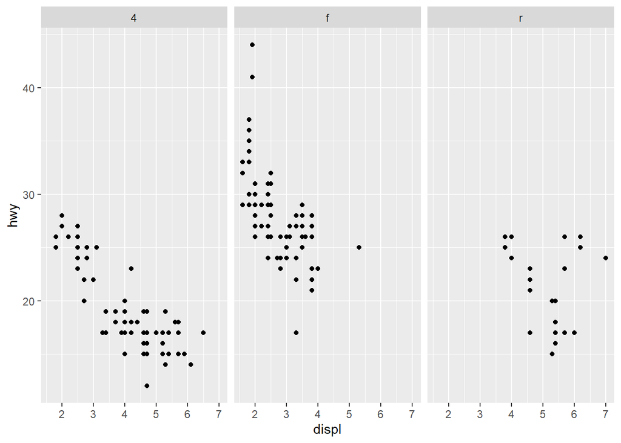

- Densidad: Crea un gráfico de densidad de hwy separado por el tipo de tracción (drv).

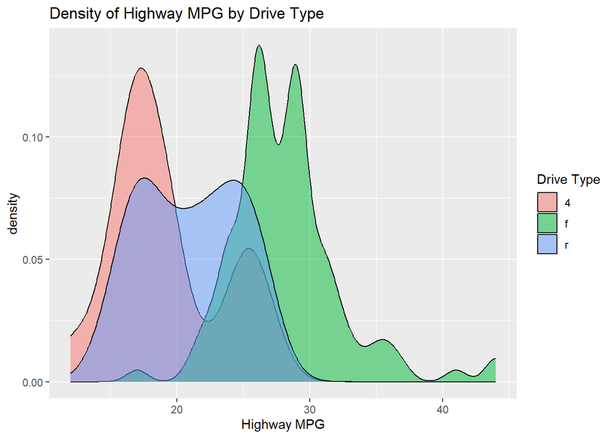

- Gráfico de línea: Crea un gráfico de línea que muestre cómo hwy varía con displ para cada fabricante (manufacturer).

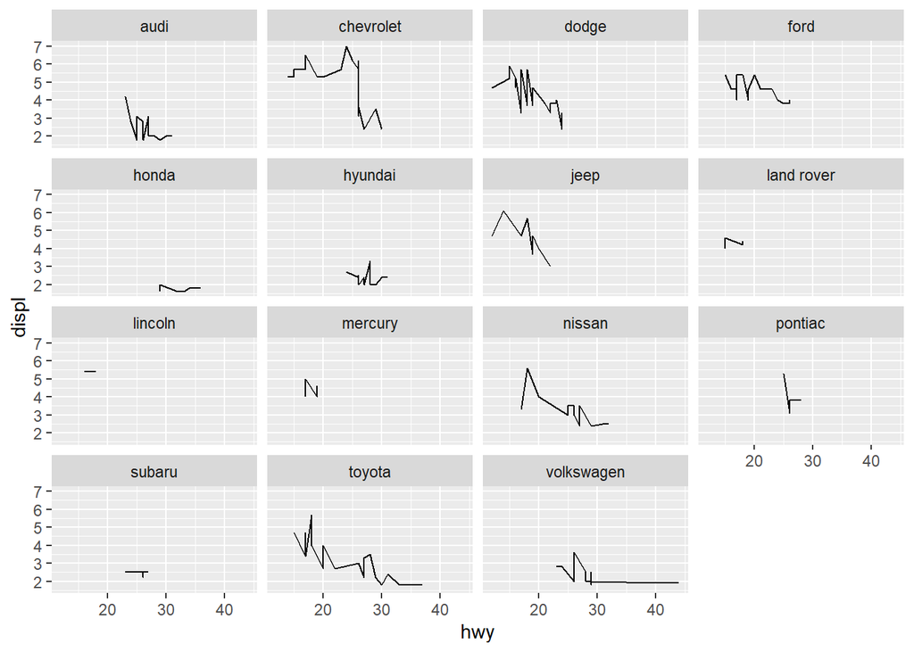

- Gráfico de puntos con tamaños: Realiza un gráfico de dispersión de displ vs hwy, donde el tamaño de los puntos esté determinado por cyl (número de cilindros).

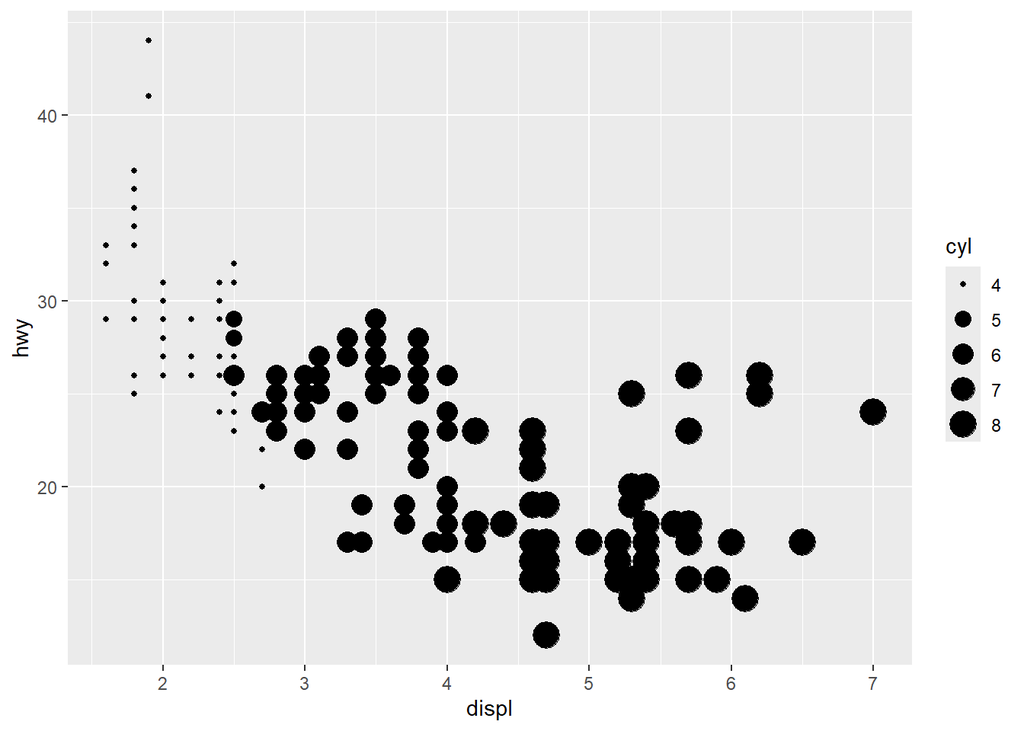

- Gráfico de mosaico: Crea un gráfico de mosaico para explorar la relación entre drv y class.

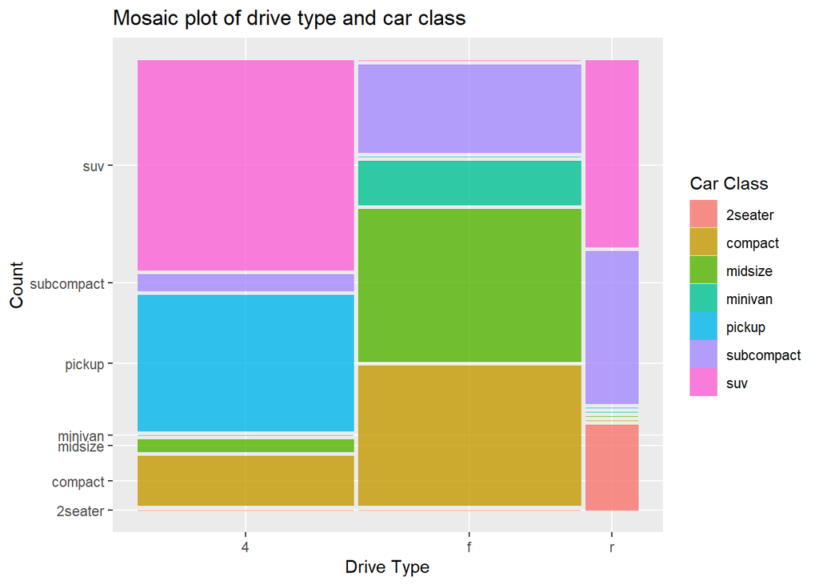

- Gráfico de violín: Realiza un gráfico de violín para comparar la distribución de hwy entre diferentes fabricantes (manufacturer).

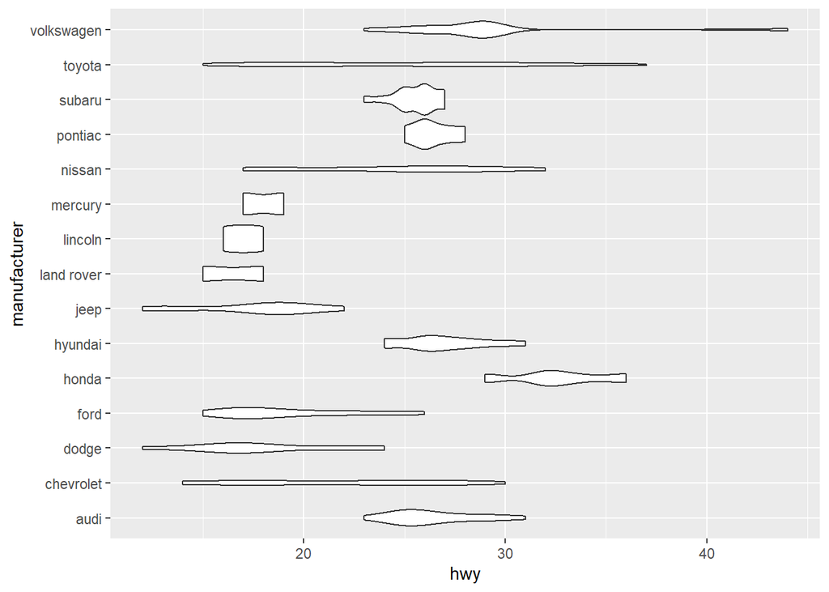